# Assignment 3

```r
library(tidyverse)
library(nycflights13)
```

# 3.8.1 Exercises

1. What is the problem with this plot? How could you improve it?

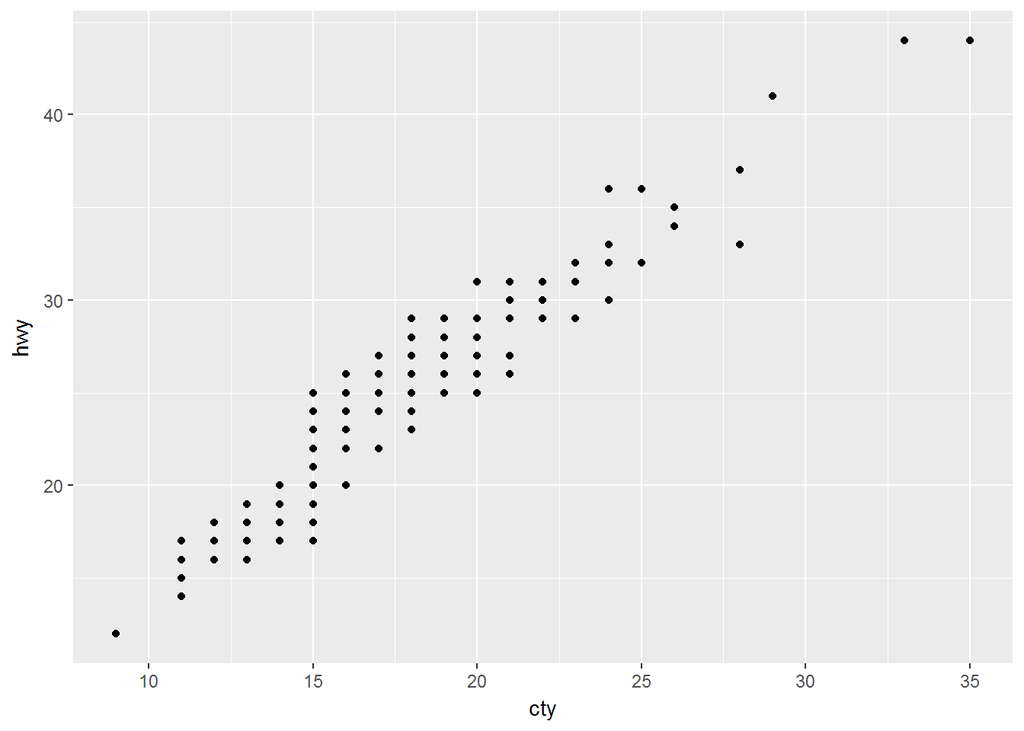

```r
ggplot(data = mpg, mapping = aes(x = cty, y = hwy)) +
  geom_point()
```

There is high overlap of points due to which it is hard to determine where highest concentration of observations lies. To offset the problem, we can use jitter to add a small noise to the data and have discrete points on scatterplot. Updated graph with jittering is as follows:

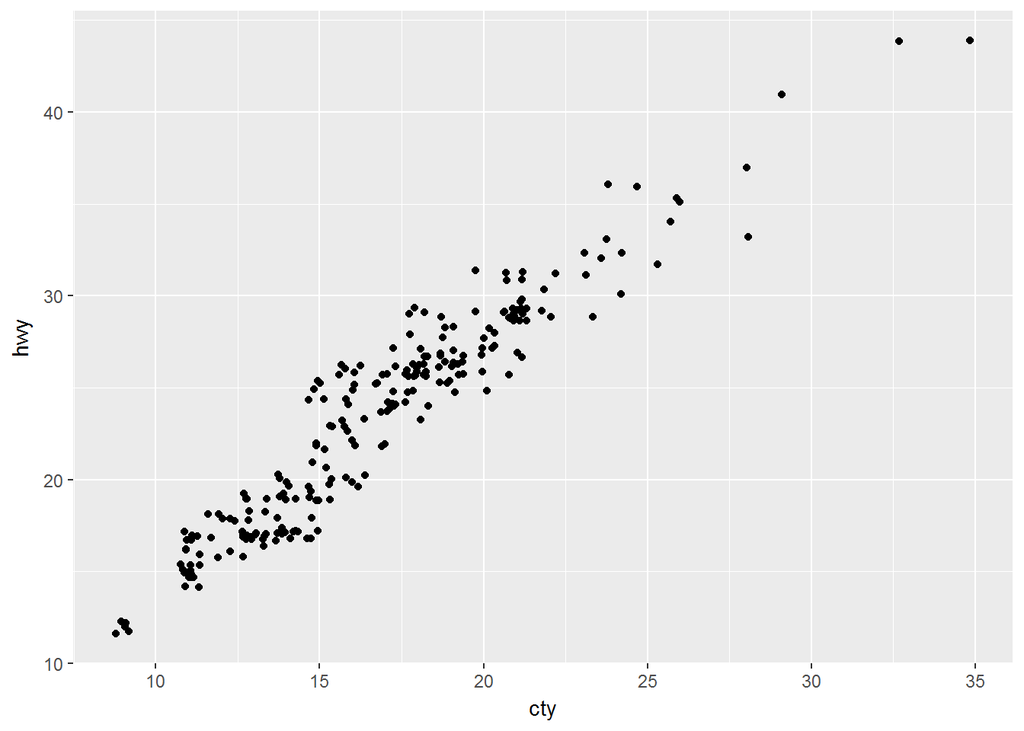

```r
ggplot(mpg, aes(cty,hwy))+
  geom_jitter()
```

2. What parameters to geom_jitter() control the amount of jittering?

Geom_jitter() takes width and height as 2 parameters to control amount of horizontal and vertical jittering

3. Compare and contrast geom_jitter() with geom_count()

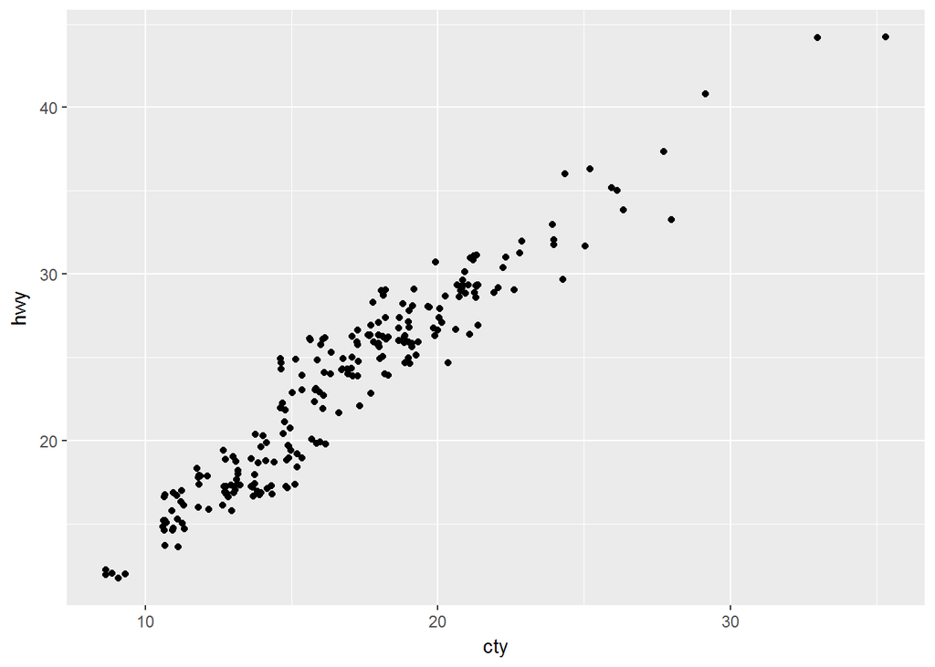

```r
ggplot(mpg,aes(cty,hwy))+
  geom_jitter()
```

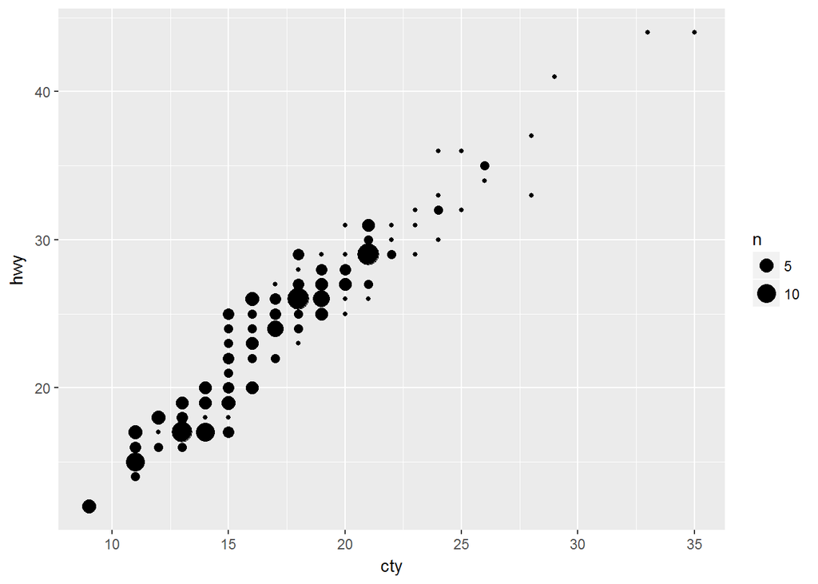

```r
ggplot(mpg,aes(cty,hwy))+
  geom_count()
```

geom_count() - maps count of observations to point area.The higher concentration of points are represented with bigger point area. This can be easier to read as compared to jitter where all points are shown with random noise.

4. What’s the default position adjustment for geom_boxplot() ? Create a visualization of the mpg dataset that demonstrates it. Position_dodge() is default position adjustment if a third variable is added to boxplot().

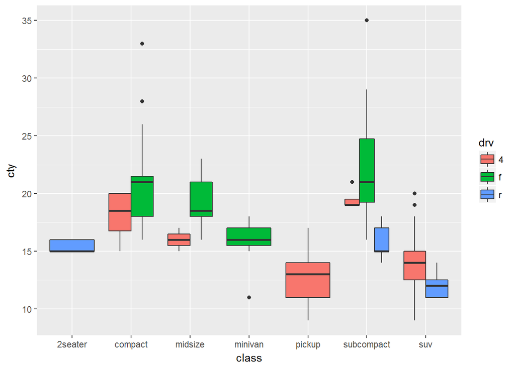

```r
ggplot(mpg,aes(class,cty,fill=drv))+
  geom_boxplot()
```

# 3.9.1 Exercises

1. Turn a stacked bar chart into a pie chart using coord_polar()

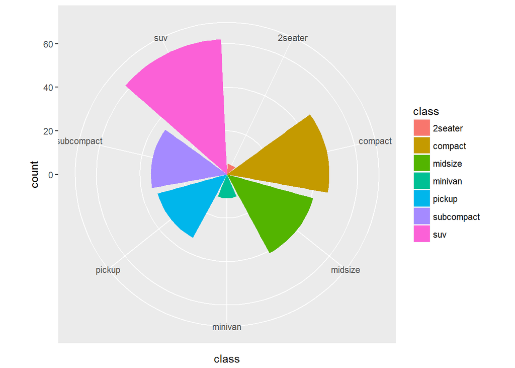

```r
ggplot(mpg)+
  geom_bar(aes(class,fill=class))+
  coord_polar()
```

2. What does labs() do? Read the documentation.

Labs manages labeling for the graph - it can be used to add labels to x, y axis or legend, give title and subtitle or even include a caption.

4. What does the plot below tell you about the relationship between city and highway mpg? Why is coord_fixed() important? What does geom_abline() do?

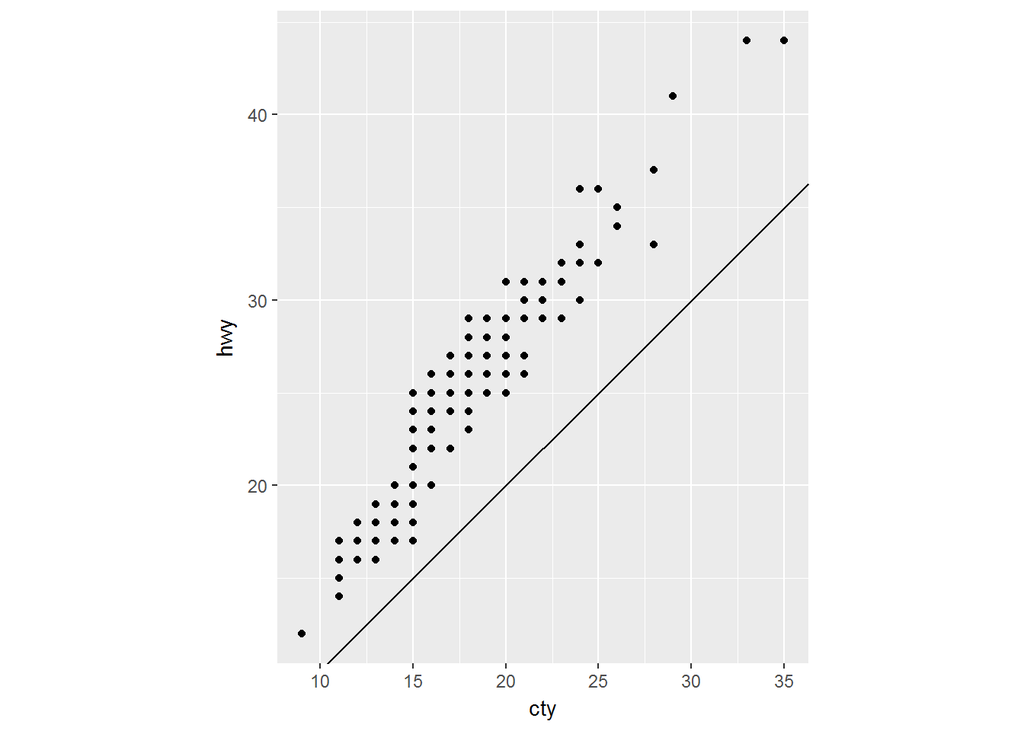

```r
ggplot(data = mpg, mapping = aes(x = cty, y = hwy)) +
  geom_point() +
  geom_abline()+
  coord_fixed()
```

The graphs shows linear positive correlation of two variables - cty and hwy. Overall cars have higher highway mileage as compared to city mileage (values going towards 40 and above on y-axis). Through abline() function, the straight line got added with default slope, intercept and elevation of 45 degrees. Coord_fixed() is giving a fixed scale to the graph - 1 unit of x axis is same as 1 unit of y axis. This is important as here the units of x-axis and y-axis are same, and without coord_fixed() the physical representation of axes will be disproportionate. The important observation of highway mileage being relatively higher than city mileage would not have come out easily if coord_fixed() was not used